# Lab 6 - things that can go wrong

Ilaria Prosdocimi

# Boston housing - linearità

Prendiamo in esame il dataset *Boston* nel pacchetto `MASS`.

```r
library(MASS)
data(Boston, package = "MASS")
help(Boston, package = "MASS")
```

```
## avvio in corso del server httpd per la guida ... fatto
```

Il dataset contiene informazioni sui prezzi delle case in varie zone di Boston e dintorni. La variabile di interesse è `medv`, il prezzo mediano (in USD) delle caso di proprietà della zona. Per questo lab ci concentriamo sulla relazione tra la variabile `lstat`, che descrive la proporzione della popolazione che viene registrata in una bassa fascia di reddito nella zona.

Diamo un’occhiata alla relazione tra le due variabili (provando anche a stimare un modello lineare semplice):

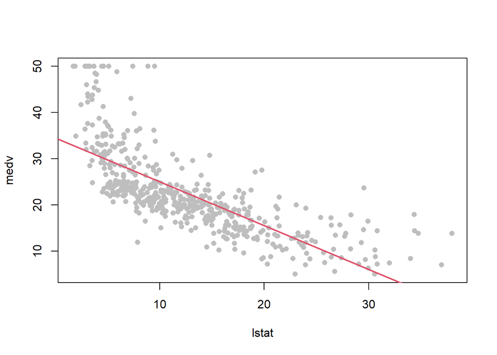

```r
plot(medv ~ lstat, data = Boston, pch = 16, col = "grey")
fit1 <- lm(medv ~ lstat, data = Boston)
abline(fit1, col = 2, lwd = 2)
```

L’assunzione di linearità della relazione non sembra molto valida, questo è anche evidente guardando i vari grafici dei residui:

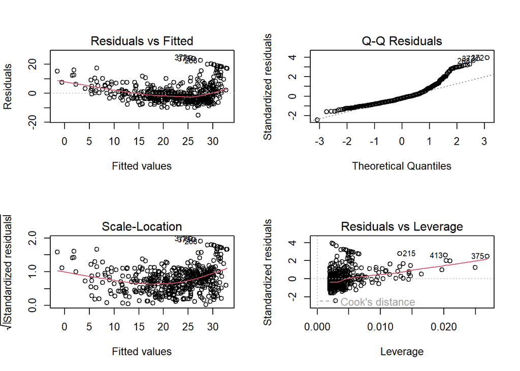

```r
par(mfrow = c(2,2))
plot(fit1)
```

Proviamo a stimare un modello più complesso, per esempio un polinomio di ordine 2

```r
# beta0 + beta1 * x + beta2 * x^2
Boston$lstat2 <- Boston$lstat^2
lm(medv ~ lstat + lstat2, data = Boston)
```

```
##
## Call:
## lm(formula = medv ~ lstat + lstat2, data = Boston)
##
## Coefficients:
## (Intercept)        lstat       lstat2
##    42.86201     -2.33282      0.04355
```

```r
fit2 <- lm(medv ~ lstat + I(lstat^2), data = Boston)
fit2
```

```
##
## Call:
## lm(formula = medv ~ lstat + I(lstat^2), data = Boston)
##
## Coefficients:
## (Intercept)        lstat   I(lstat^2)
##    42.86201     -2.33282      0.04355
```

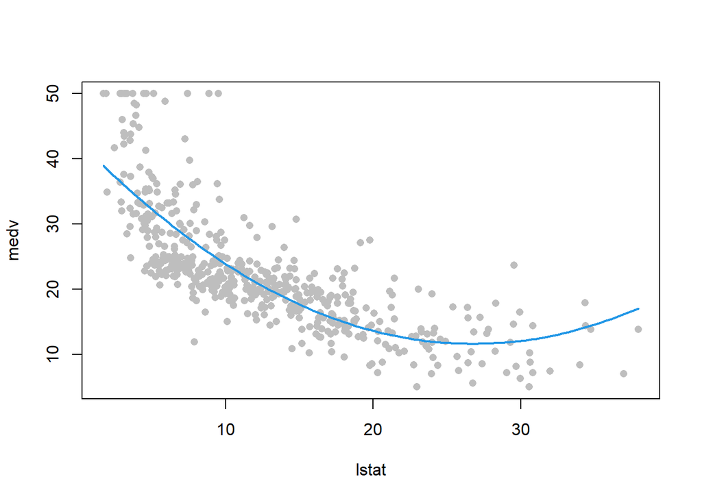

```r
par(mfrow= c(1,1))
plot(medv ~ lstat, data = Boston, pch = 16, col = "grey")
curve(fit2$coef[1] + fit2$coef[2] * x + fit2$coef[3] * x^2, col = 4, lwd = 2, add = TRUE)
```

```r
fit2p <- lm(medv ~ poly(lstat, 2), data = Boston)
fit2p
```

```
##
## Call:
## lm(formula = medv ~ poly(lstat, 2), data = Boston)
##
## Coefficients:
##     (Intercept)  poly(lstat, 2)1  poly(lstat, 2)2
##           22.53          -152.46            64.23
```

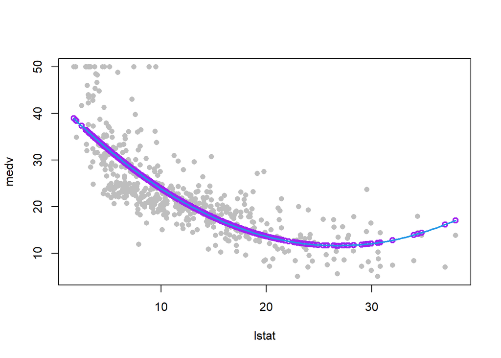

```r
plot(medv ~ lstat, data = Boston, pch = 16, col = "grey")
points(Boston$lstat, fitted(fit2p), col = "purple", lwd = 2, add = TRUE)
curve(fit2$coef[1] + fit2$coef[2] * x + fit2$coef[3] * x^2, col = 4, lwd = 2, add = TRUE)
```

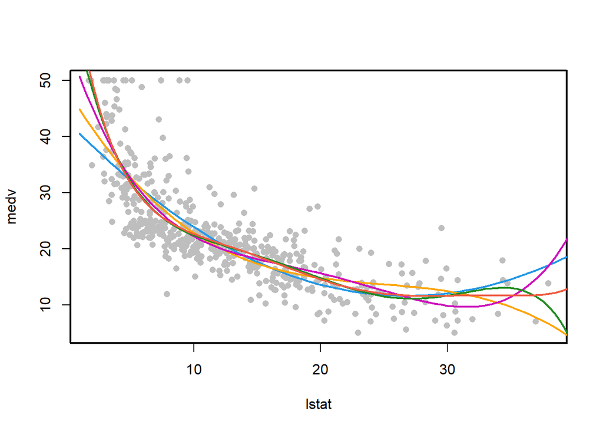

```r
par(mfrow = c(1,1), lwd = 2)
fit3p <- lm(medv ~ poly(lstat,3), data = Boston)
fit4p <- lm(medv ~ poly(lstat,4), data = Boston)
fit5p <- lm(medv ~ poly(lstat,5), data = Boston)
fit6p <- lm(medv ~ poly(lstat,6), data = Boston)
nd <- data.frame(lstat = seq(1,40, by = 0.5))
plot(medv ~ lstat, data = Boston, pch = 16, col = "grey")
lines(nd$lstat, predict(fit2p, newdata = nd), col = 4)
lines(nd$lstat, predict(fit3p, newdata = nd), col = "orange")
lines(nd$lstat, predict(fit4p, newdata = nd), col = 6)
lines(nd$lstat, predict(fit5p, newdata = nd), col = "forestgreen")
lines(nd$lstat, predict(fit6p, newdata = nd), col = "tomato2")
```

```r
head(model.matrix(fit6p))
```

```
##   (Intercept) poly(lstat, 6)1 poly(lstat, 6)2 poly(lstat, 6)3 poly(lstat, 6)4
## 1           1     -0.04781458      0.03895455     -0.01906462    -0.005439764
## 2           1     -0.02189160     -0.01078168      0.03564769    -0.033207312
## 3           1     -0.05373449      0.05360400     -0.04390947     0.025948246
## 4           1     -0.06052681      0.07191994     -0.07909404     0.078957668
## 5           1     -0.04563356      0.03386588     -0.01119724    -0.013993411
## 6           1     -0.04638134      0.03559186     -0.01381903    -0.011229907
##   poly(lstat, 6)5 poly(lstat, 6)6
## 1    2.971418e-02     -0.04218558
## 2    3.243484e-03      0.02874843
## 3   -1.748063e-05     -0.02534474
## 4   -6.798137e-02      0.04648714
## 5    3.535552e-02     -0.04150031
## 6    3.369972e-02     -0.04205610
```

```r
cor(model.matrix(fit6p)[,-1])
```

```
##                 poly(lstat, 6)1 poly(lstat, 6)2 poly(lstat, 6)3 poly(lstat, 6)4
## poly(lstat, 6)1    1.000000e+00   -1.108117e-16    2.045521e-17   -6.451321e-17
## poly(lstat, 6)2   -1.108117e-16    1.000000e+00   -2.240135e-16    1.632410e-17
## poly(lstat, 6)3    2.045521e-17   -2.240135e-16    1.000000e+00   -4.683182e-17
## poly(lstat, 6)4   -6.451321e-17    1.632410e-17   -4.683182e-17    1.000000e+00
## poly(lstat, 6)5   -4.167720e-17    4.301839e-17    9.920556e-18    5.020814e-17
## poly(lstat, 6)6   -1.572948e-17    5.277106e-17    2.998837e-17    2.626236e-17
##                 poly(lstat, 6)5 poly(lstat, 6)6
## poly(lstat, 6)1   -4.167720e-17   -1.572948e-17
## poly(lstat, 6)2    4.301839e-17    5.277106e-17
## poly(lstat, 6)3    9.920556e-18    2.998837e-17
## poly(lstat, 6)4    5.020814e-17    2.626236e-17
## poly(lstat, 6)5    1.000000e+00    1.780501e-16
## poly(lstat, 6)6    1.780501e-16    1.000000e+00
```

```r
head(model.matrix(lm(medv ~ poly(lstat,6, raw = TRUE), data = Boston)))
```

```
##   (Intercept) poly(lstat, 6, raw = TRUE)1 poly(lstat, 6, raw = TRUE)2
## 1           1                        4.98                     24.8004
## 2           1                        9.14                     83.5396
## 3           1                        4.03                     16.2409
## 4           1                        2.94                      8.6436
## 5           1                        5.33                     28.4089
## 6           1                        5.21                     27.1441
##   poly(lstat, 6, raw = TRUE)3 poly(lstat, 6, raw = TRUE)4
## 1                   123.50599                   615.05984
## 2                   763.55194                  6978.86477
## 3                    65.45083                   263.76683
## 4                    25.41218                    74.71182
## 5                   151.41944                   807.06560
## 6                   141.42076                   736.80216
##   poly(lstat, 6, raw = TRUE)5 poly(lstat, 6, raw = TRUE)6
## 1                   3062.9980                  15253.7301
## 2                  63786.8240                 583011.5712
## 3                   1062.9803                   4283.8108
## 4                    219.6528                    645.7791
## 5                   4301.6596                  22927.8459
## 6                   3838.7393                  19999.8316
```

```r
cor(model.matrix(lm(medv ~ poly(lstat,6, raw = TRUE), data = Boston))[,-1])
```

```
##                             poly(lstat, 6, raw = TRUE)1
## poly(lstat, 6, raw = TRUE)1                   1.0000000
## poly(lstat, 6, raw = TRUE)2                   0.9605726
## poly(lstat, 6, raw = TRUE)3                   0.8788131
## poly(lstat, 6, raw = TRUE)4                   0.7911773
## poly(lstat, 6, raw = TRUE)5                   0.7115262
## poly(lstat, 6, raw = TRUE)6                   0.6427900
##                             poly(lstat, 6, raw = TRUE)2
## poly(lstat, 6, raw = TRUE)1                   0.9605726
## poly(lstat, 6, raw = TRUE)2                   1.0000000
## poly(lstat, 6, raw = TRUE)3                   0.9748582
## poly(lstat, 6, raw = TRUE)4                   0.9216147
## poly(lstat, 6, raw = TRUE)5                   0.8606340
## poly(lstat, 6, raw = TRUE)6                   0.8006829
##                             poly(lstat, 6, raw = TRUE)3
## poly(lstat, 6, raw = TRUE)1                   0.8788131
## poly(lstat, 6, raw = TRUE)2                   0.9748582
## poly(lstat, 6, raw = TRUE)3                   1.0000000
## poly(lstat, 6, raw = TRUE)4                   0.9840069
## poly(lstat, 6, raw = TRUE)5                   0.9484004
## poly(lstat, 6, raw = TRUE)6                   0.9049296
##                             poly(lstat, 6, raw = TRUE)4
## poly(lstat, 6, raw = TRUE)1                   0.7911773
## poly(lstat, 6, raw = TRUE)2                   0.9216147
## poly(lstat, 6, raw = TRUE)3                   0.9840069
## poly(lstat, 6, raw = TRUE)4                   1.0000000
## poly(lstat, 6, raw = TRUE)5                   0.9892770
## poly(lstat, 6, raw = TRUE)6                   0.9642872
##                             poly(lstat, 6, raw = TRUE)5
## poly(lstat, 6, raw = TRUE)1                   0.7115262
## poly(lstat, 6, raw = TRUE)2                   0.8606340
## poly(lstat, 6, raw = TRUE)3                   0.9484004
## poly(lstat, 6, raw = TRUE)4                   0.9892770
## poly(lstat, 6, raw = TRUE)5                   1.0000000
## poly(lstat, 6, raw = TRUE)6                   0.9924210
##                             poly(lstat, 6, raw = TRUE)6
## poly(lstat, 6, raw = TRUE)1                   0.6427900
## poly(lstat, 6, raw = TRUE)2                   0.8006829
## poly(lstat, 6, raw = TRUE)3                   0.9049296
## poly(lstat, 6, raw = TRUE)4                   0.9642872
## poly(lstat, 6, raw = TRUE)5                   0.9924210
## poly(lstat, 6, raw = TRUE)6                   1.0000000
```

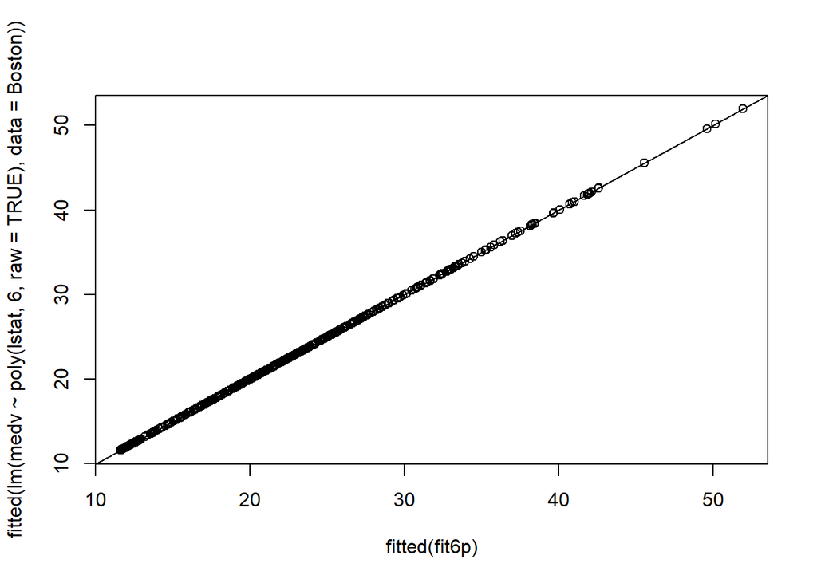

```r
plot(fitted(fit6p), fitted(lm(medv ~ poly(lstat,6, raw = TRUE), data = Boston)))
abline(0,1)
```

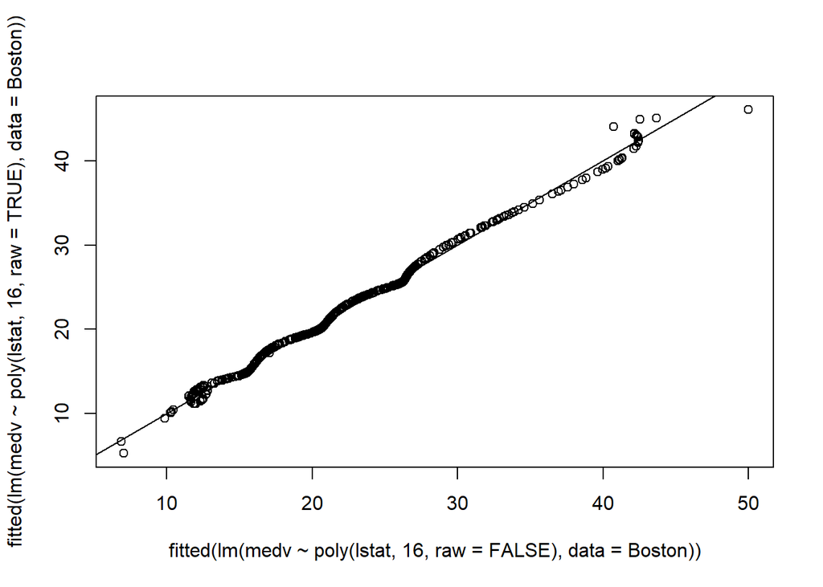

```r
plot(fitted(lm(medv ~ poly(lstat,16, raw = FALSE), data = Boston)),
     fitted(lm(medv ~ poly(lstat,16, raw = TRUE), data = Boston)))
abline(0,1)
```

```r
# iniziamo ad avere instabilità numerica
```

```r
a <- AIC(fit2p, fit3p, fit4p, fit5p, fit6p)
a[order(a[,2]),]
```

```
##       df      AIC
## fit5p  7 3115.247
## fit6p  8 3115.668
## fit4p  6 3126.856
## fit3p  5 3147.796
## fit2p  4 3170.516
```

```r
anova(fit4p, fit6p)
```

```
## Analysis of Variance Table
##
## Model 1: medv ~ poly(lstat, 4)
## Model 2: medv ~ poly(lstat, 6)
##   Res.Df   RSS Df Sum of Sq      F    Pr(>F)
## 1    501 13968
## 2    499 13555  2    413.02 7.6024 0.0005593 ***
## ---
## Signif. codes:  0 '***' 0.001 '**' 0.01 '*' 0.05 '.' 0.1 ' ' 1
```

```r
a <- AIC(fit2p, fit3p, fit4p, fit5p, fit6p, k = log(nrow(Boston)))
a[order(a[,2]),]
```

```
##       df      AIC
## fit5p  7 3144.833
## fit6p  8 3149.481
## fit4p  6 3152.216
## fit3p  5 3168.928
## fit2p  4 3187.422
```

Teniamo il polinomiio di ordine 5

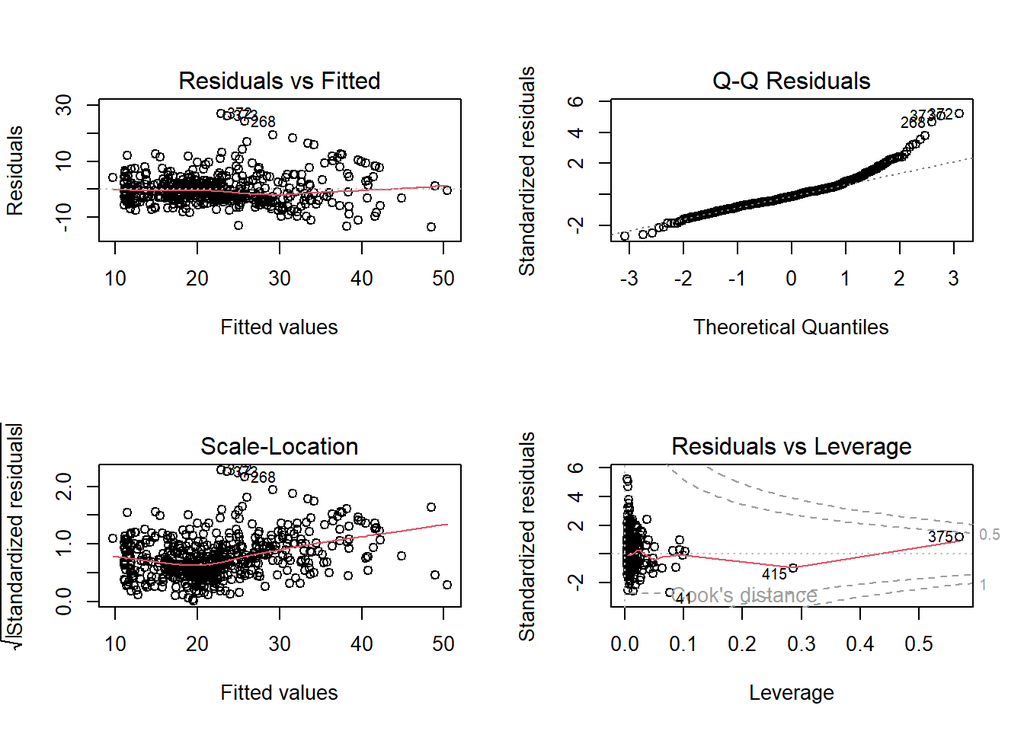

```r
par(mfrow=c(2,2))
plot(fit5p)
```

```r
par(mfrow=c(1,1))
bct <- boxcox(fit5p, lambda = seq(-0.5, 0.8, by = 0.05))
```

[figure not shown]

```r
bct$x[bct$y == max(bct$y)]
```

```
## [1] 0.2616162
```

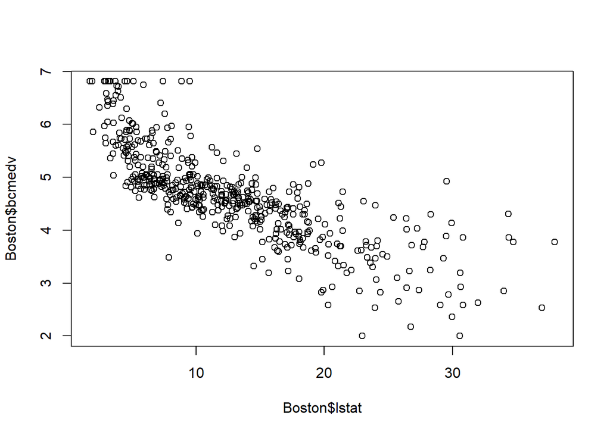

```r
optlambda <- bct$x[which.max(bct$y)]
Boston$bcmedv <- (Boston$medv^optlambda - 1)/optlambda
plot(Boston$lstat, Boston$bcmedv)
```

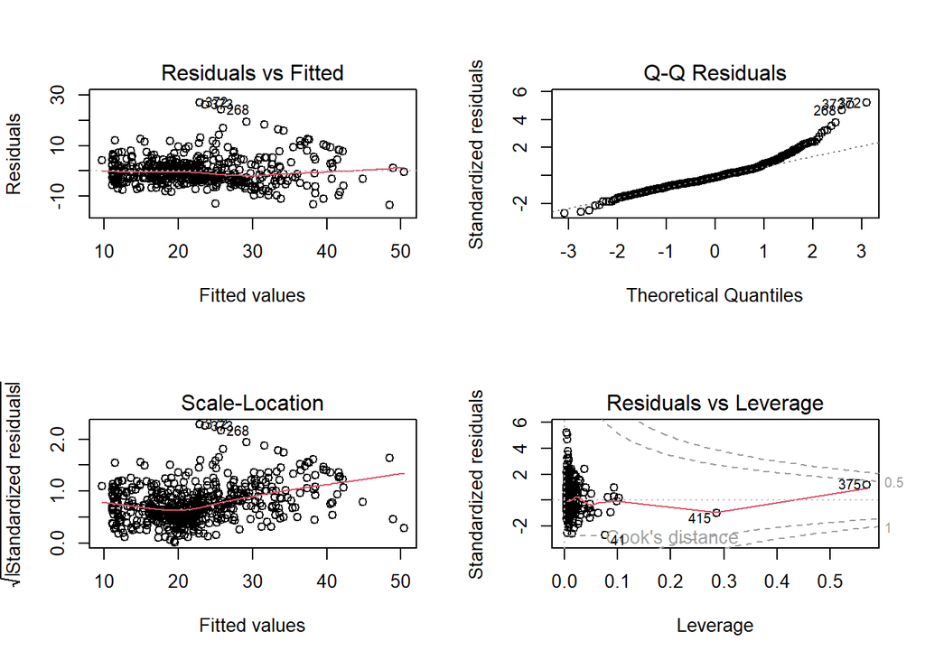

```r
par(mfrow = c(2,2))
plot(fit5p)
```

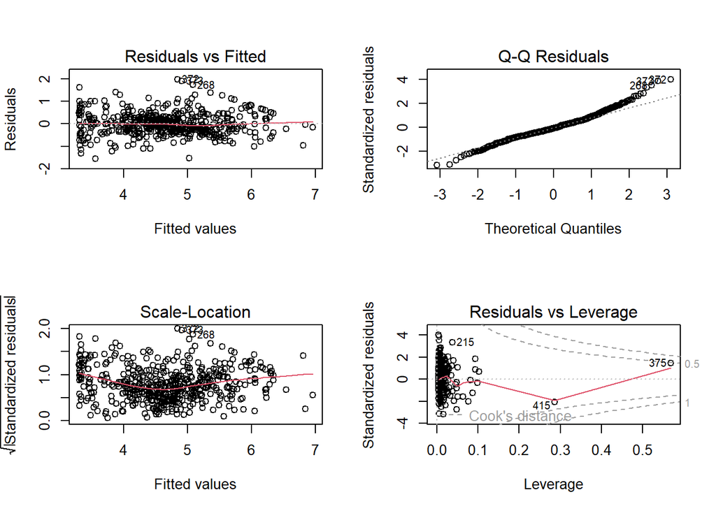

```r
plot(lm(bcmedv ~ poly(lstat, 5), data = Boston))
```

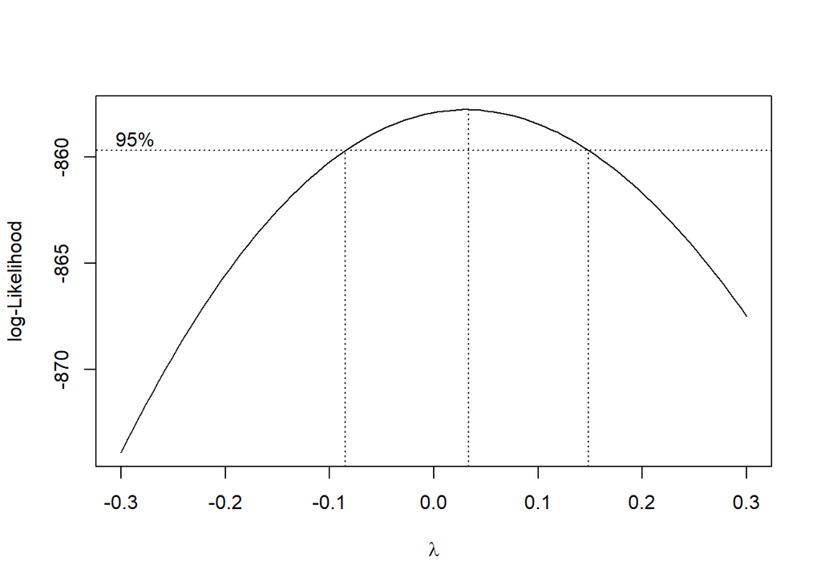

```r
par(mfrow = c(1,1))
boxcox(fit1, lambda = seq(-0.3, 0.3, length.out = 100))
```

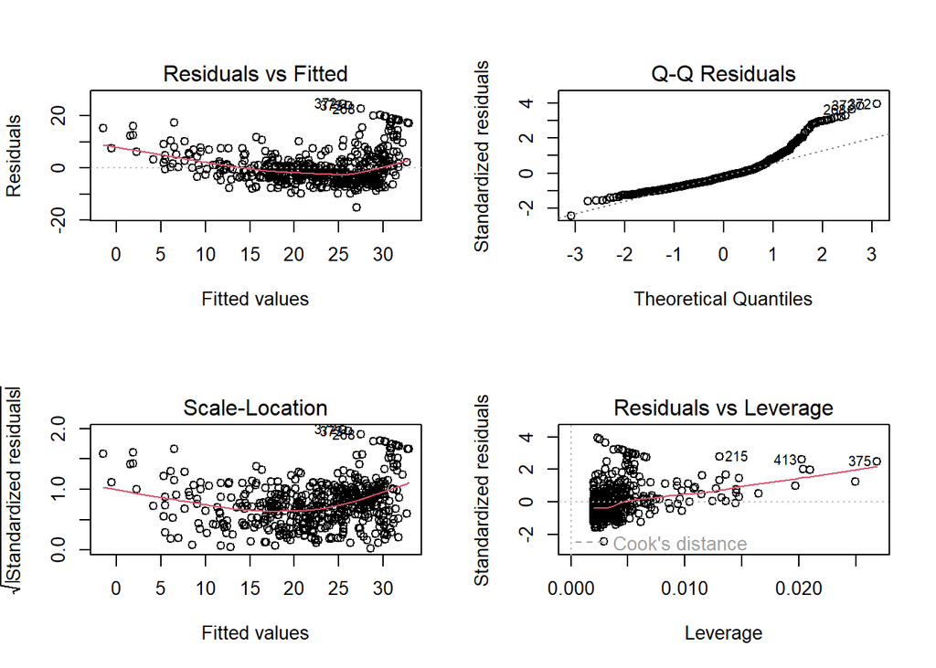

```r
par(mfrow = c(2,2))
plot(fit1)
```

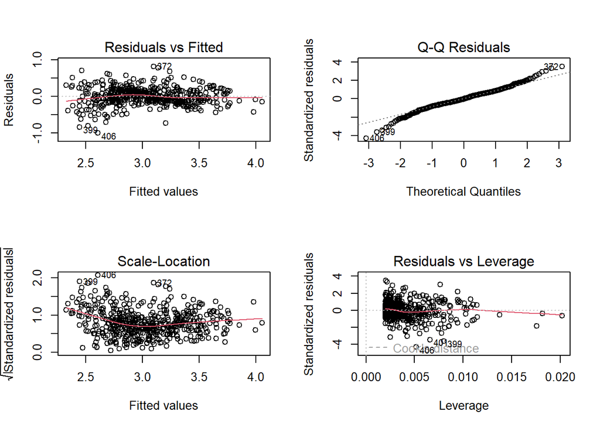

```r
par(mfrow = c(2,2))
plot(lm(log(medv)  ~ log(lstat), data = Boston))
```

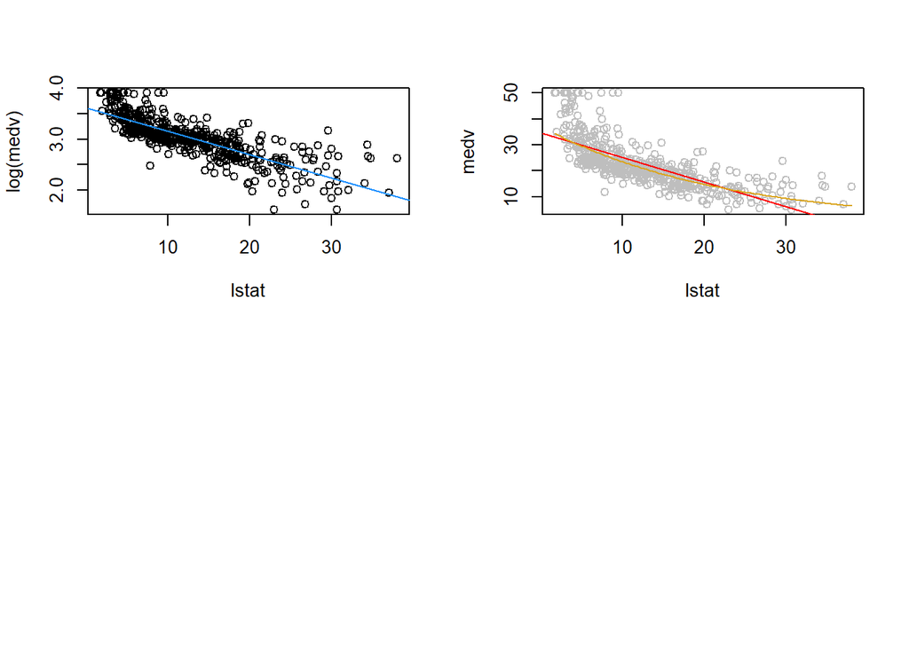

```r
fit1log <- lm(log(medv)  ~ lstat, data = Boston)
plot(log(medv)  ~ lstat, data = Boston)
abline(fit1log, col = "dodgerblue")
plot(medv  ~ lstat, data = Boston, col = "grey")
abline(fit1, col = "red")
curve(exp(coef(fit1log)[1] + coef(fit1log)[2]*x), col = "dodgerblue", add = TRUE)
curve(exp(coef(fit1log)[1]) * exp(coef(fit1log)[2]*x), col = "goldenrod", add = TRUE)
```

# Body fat

Prendiamo in esame il dataset `bodyfat` che abbiamo già usato in un esercizio. Leggiamo i dati e trasformiamo altezza e peso dalle misure imperiali (libbre e pollici) a misure decimali (Kg e cm).

```r
# urlLocation <- "https://dasl.datadescription.com/download/data/3079"
# bodyfat <- read.table(urlLocation, header=TRUE)
bodyfat <- read.csv("../data/bodyfat.csv",header = TRUE)
bodyfat$Height <- bodyfat$Height * 2.54
bodyfat$Weight <- bodyfat$Weight / 2.205
bodyfat <- bodyfat[, -17]
#plot(bodyfat)
```

Una descrizione completa del dataset è disponibile [qui](http://jse.amstat.org/datasets/fat.txt); le variabili contenute nel dataset sono:

- Density: Percent body fat using Brozek’s equation, 457/Density - 414.2
- Pct.BF: Percent body fat using Siri’s equation, 495/Density - 450
- Age: Age (yrs)
- Weight: Weight (lbs)
- Height: Height (inches)
- Neck: Neck circumference (cm)
- Chest Chest circumference (cm)
- Abdomen/Waist: Abdomen circumference (cm) “at the umbilicus and level with the iliac crest”
- Hip: Hip circumference (cm)
- Thigh: Thigh circumference (cm)
- Knee: Knee circumference (cm)
- Ankle: Ankle circumference (cm)
- Bicep: Extended biceps circumference (cm)
- Forearm: Forearm circumference (cm)
- Wrist: Wrist circumference (cm) “distal to the styloid processes”

Si desidera costruire un modello per predire la percentuale di materia grassa di un individuo a partire dalle altre variabili. Possiamo iniziare con un modello che contenga tutti le variabili contenute nel dataset come predittori (tranne `Density`):

```r
## remove density
fit_all <- lm(Pct.BF~., data = bodyfat[,-1])
summary(fit_all)
```

```
##
## Call:
## lm(formula = Pct.BF ~ ., data = bodyfat[, -1])
##
## Residuals:
##      Min       1Q   Median       3Q      Max
## -10.9900  -3.1244  -0.1674   3.0248   9.8648
##
## Coefficients: (1 not defined because of singularities)
##             Estimate Std. Error t value Pr(>|t|)
## (Intercept)  1.68516   23.37412   0.072 0.942587
## Age          0.07189    0.03217   2.234 0.026389 *
## Weight      -0.03886    0.14804  -0.263 0.793153
## Height      -0.09715    0.07525  -1.291 0.197989
## Neck        -0.38682    0.23486  -1.647 0.100887
## Chest       -0.11919    0.10825  -1.101 0.272004
## Abdomen      0.90452    0.09140   9.897  < 2e-16 ***
## Waist             NA         NA      NA       NA
## Hip         -0.15878    0.14586  -1.089 0.277446
## Thigh        0.17299    0.14683   1.178 0.239926
## Knee        -0.04580    0.24560  -0.186 0.852230
## Ankle        0.18502    0.21985   0.842 0.400862
## Bicep        0.17968    0.17039   1.054 0.292732
## Forearm      0.27605    0.20692   1.334 0.183454
## Wrist       -1.80162    0.53304  -3.380 0.000848 ***
## ---
## Signif. codes:  0 '***' 0.001 '**' 0.01 '*' 0.05 '.' 0.1 ' ' 1
##
## Residual standard error: 4.255 on 236 degrees of freedom
## Multiple R-squared:  0.7505, Adjusted R-squared:  0.7368
## F-statistic: 54.61 on 13 and 236 DF,  p-value: < 2.2e-16
```

`Waist` e `Abdomen` sono perfettamente co-lineari, non è possibile stimare l’effetto di entrambe le variabili nel modello:

```r
summary(lm(Pct.BF~Abdomen, data = bodyfat[,-1]))
```

```
##
## Call:
## lm(formula = Pct.BF ~ Abdomen, data = bodyfat[, -1])
##
## Residuals:
##      Min       1Q   Median       3Q      Max
## -10.8987  -3.6453   0.1864   3.1775  12.7887
##
## Coefficients:
##              Estimate Std. Error t value Pr(>|t|)
## (Intercept) -42.73413    2.71651  -15.73   <2e-16 ***
## Abdomen       0.66928    0.02926   22.88   <2e-16 ***
## ---
## Signif. codes:  0 '***' 0.001 '**' 0.01 '*' 0.05 '.' 0.1 ' ' 1
##
## Residual standard error: 4.713 on 248 degrees of freedom
## Multiple R-squared:  0.6785, Adjusted R-squared:  0.6772
## F-statistic: 523.3 on 1 and 248 DF,  p-value: < 2.2e-16
```

```r
summary(lm(Pct.BF~Waist, data = bodyfat[,-1]))
```

```
##
## Call:
## lm(formula = Pct.BF ~ Waist, data = bodyfat[, -1])
##
## Residuals:
##      Min       1Q   Median       3Q      Max
## -10.8987  -3.6453   0.1864   3.1775  12.7887
##
## Coefficients:
##              Estimate Std. Error t value Pr(>|t|)
## (Intercept) -42.73413    2.71651  -15.73   <2e-16 ***
## Waist         1.69997    0.07431   22.88   <2e-16 ***
## ---
## Signif. codes:  0 '***' 0.001 '**' 0.01 '*' 0.05 '.' 0.1 ' ' 1
##
## Residual standard error: 4.713 on 248 degrees of freedom
## Multiple R-squared:  0.6785, Adjusted R-squared:  0.6772
## F-statistic: 523.3 on 1 and 248 DF,  p-value: < 2.2e-16
```

```r
cor(bodyfat$Waist, bodyfat$Abdomen)
```

```
## [1] 1
```

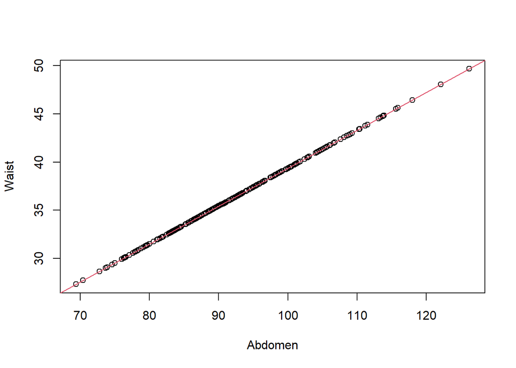

```r
plot(Waist~Abdomen, data = bodyfat); abline(lm(Waist~Abdomen, data = bodyfat), col = 2)
```

```r
## remove density and abdomen
fit_all <- lm(Pct.BF~., data = bodyfat[,-which(names(bodyfat) %in% c("Density", "Abdomen"))])
summary(fit_all)
```

```
##
## Call:
## lm(formula = Pct.BF ~ ., data = bodyfat[, -which(names(bodyfat) %in%
##     c("Density", "Abdomen"))])
##
## Residuals:
##      Min       1Q   Median       3Q      Max
## -10.9900  -3.1244  -0.1674   3.0248   9.8648
##
## Coefficients:
##             Estimate Std. Error t value Pr(>|t|)
## (Intercept)  1.68516   23.37412   0.072 0.942587
## Age          0.07189    0.03217   2.234 0.026389 *
## Weight      -0.03886    0.14804  -0.263 0.793153
## Height      -0.09715    0.07525  -1.291 0.197989
## Neck        -0.38682    0.23486  -1.647 0.100887
## Chest       -0.11919    0.10825  -1.101 0.272004
## Waist        2.29748    0.23215   9.897  < 2e-16 ***
## Hip         -0.15878    0.14586  -1.089 0.277446
## Thigh        0.17299    0.14683   1.178 0.239926
## Knee        -0.04580    0.24560  -0.186 0.852230
## Ankle        0.18502    0.21985   0.842 0.400862
## Bicep        0.17968    0.17039   1.054 0.292733
## Forearm      0.27605    0.20692   1.334 0.183454
## Wrist       -1.80162    0.53304  -3.380 0.000848 ***
## ---
## Signif. codes:  0 '***' 0.001 '**' 0.01 '*' 0.05 '.' 0.1 ' ' 1
##
## Residual standard error: 4.255 on 236 degrees of freedom
## Multiple R-squared:  0.7505, Adjusted R-squared:  0.7368
## F-statistic: 54.61 on 13 and 236 DF,  p-value: < 2.2e-16
```

In modello è significativo contro il modello nullo (il p-value per la statistica F è basso) ma solo alcuni dei predittori risultano essere significativi, e alcune stime hanno un segno che indica una relazione opposta a quella che ci si potrebbe aspettare e che si trova quando si stima la relazione tra il singolo predittore e la variabile risposta:

```r
coef(lm(Pct.BF~Chest, data = bodyfat))
```

```
## (Intercept)       Chest
## -52.7122498   0.7127203
```

```r
coef(fit_all)["Chest"]
```

```
##      Chest
## -0.1191888
```

Guardiamo per esempio alle relazioni bivariate tra $X_j$ e $Y$

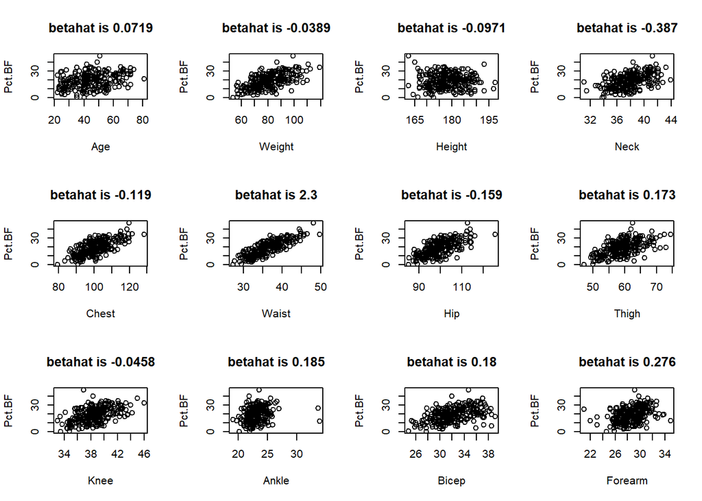

```r
par(mfrow= c(3,4))
for(j in 2:13){
  plot(bodyfat[,-which(names(bodyfat) %in% c("Density", "Abdomen"))][,c(j,1)])
  title(main = paste("betahat is", signif(coef(fit_all)[j],3)))
}
```

Vediamo delle relazioni piuttosto forti tra i predittori ed $Y$ anche se alcuni predittori risultano non significativi. Inoltre la direzione della relazione stimata non sempre è quella che si vede nella relazione bivariate (questo ha senso perché la stima che si ottiene nei modelli lineari multipli per una variabile è l’effetto che ha $X_j$ su $Y$ *considerato l’effetto degli altri predittori su $Y$*). Cosa succede? Le variabili esplicative sono fortemente correlate tra loro:

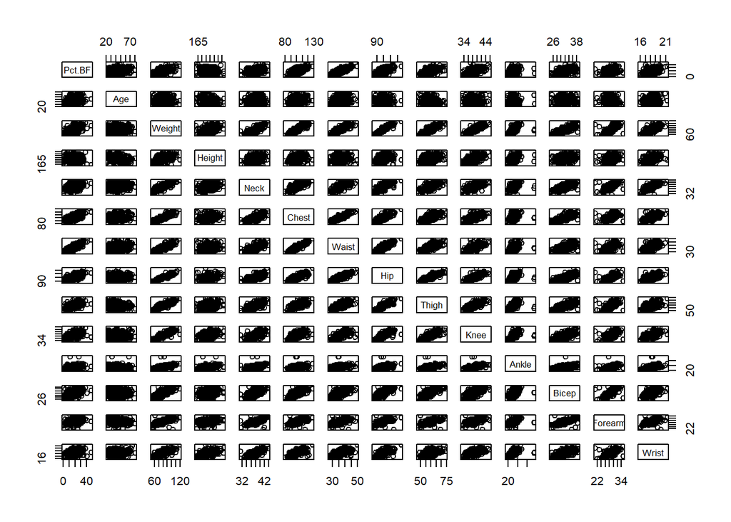

```r
plot(bodyfat[,-which(names(bodyfat) %in% c("Density", "Abdomen"))])
```

```r
signif(cor(bodyfat),3)
```

```
##         Density  Pct.BF     Age  Weight  Height   Neck  Chest Abdomen  Waist
## Density  1.0000 -0.9870 -0.2810 -0.5980  0.0434 -0.470 -0.680  -0.809 -0.809
## Pct.BF  -0.9870  1.0000  0.2950  0.6170 -0.0294  0.489  0.701   0.824  0.824
## Age     -0.2810  0.2950  1.0000 -0.0161 -0.2460  0.119  0.182   0.243  0.243
## Weight  -0.5980  0.6170 -0.0161  1.0000  0.5130  0.810  0.891   0.874  0.874
## Height   0.0434 -0.0294 -0.2460  0.5130  1.0000  0.325  0.224   0.187  0.187
## Neck    -0.4700  0.4890  0.1190  0.8100  0.3250  1.000  0.769   0.728  0.728
## Chest   -0.6800  0.7010  0.1820  0.8910  0.2240  0.769  1.000   0.910  0.910
## Abdomen -0.8090  0.8240  0.2430  0.8740  0.1870  0.728  0.910   1.000  1.000
## Waist   -0.8090  0.8240  0.2430  0.8740  0.1870  0.728  0.910   1.000  1.000
## Hip     -0.6160  0.6330 -0.0581  0.9330  0.3970  0.708  0.825   0.861  0.861
## Thigh   -0.5430  0.5490 -0.2160  0.8520  0.3500  0.669  0.708   0.737  0.737
## Knee    -0.4790  0.4920  0.0172  0.8430  0.5130  0.648  0.698   0.710  0.710
## Ankle   -0.2440  0.2450 -0.1100  0.5810  0.3950  0.434  0.447   0.407  0.407
## Bicep   -0.4760  0.4820 -0.0441  0.7850  0.3190  0.709  0.707   0.656  0.656
## Forearm -0.3550  0.3650 -0.0851  0.6830  0.3220  0.661  0.599   0.530  0.530
## Wrist   -0.3180  0.3390  0.2180  0.7250  0.3970  0.731  0.644   0.602  0.602
##             Hip  Thigh    Knee  Ankle   Bicep Forearm  Wrist
## Density -0.6160 -0.543 -0.4790 -0.244 -0.4760 -0.3550 -0.318
## Pct.BF   0.6330  0.549  0.4920  0.245  0.4820  0.3650  0.339
## Age     -0.0581 -0.216  0.0172 -0.110 -0.0441 -0.0851  0.218
## Weight   0.9330  0.852  0.8430  0.581  0.7850  0.6830  0.725
## Height   0.3970  0.350  0.5130  0.395  0.3190  0.3220  0.397
## Neck     0.7080  0.669  0.6480  0.434  0.7090  0.6610  0.731
## Chest    0.8250  0.708  0.6980  0.447  0.7070  0.5990  0.644
## Abdomen  0.8610  0.737  0.7100  0.407  0.6560  0.5300  0.602
## Waist    0.8610  0.737  0.7100  0.407  0.6560  0.5300  0.602
## Hip      1.0000  0.881  0.8090  0.521  0.7220  0.6030  0.626
## Thigh    0.8810  1.000  0.7770  0.504  0.7440  0.6040  0.544
## Knee     0.8090  0.777  1.0000  0.585  0.6540  0.5790  0.656
## Ankle    0.5210  0.504  0.5850  1.000  0.4490  0.4290  0.545
## Bicep    0.7220  0.744  0.6540  0.449  1.0000  0.7010  0.614
## Forearm  0.6030  0.604  0.5790  0.429  0.7010  1.0000  0.598
## Wrist    0.6260  0.544  0.6560  0.545  0.6140  0.5980  1.000
```

Le diverse variabili esplicative stanno ‘’rubando’’ capacità predittiva le une alle altre: abbiamo un problema di multi-colinearità.

```r
summary(lm(Pct.BF ~ Weight, data = bodyfat))$coef
```

```
##                Estimate Std. Error   t value     Pr(>|t|)
## (Intercept) -14.6931445 2.76045092 -5.322733 2.287854e-07
## Weight        0.4175748 0.03379383 12.356542 1.189995e-27
```

```r
summary(lm(Pct.BF ~ Hip, data = bodyfat))$coef
```

```
##                Estimate Std. Error   t value     Pr(>|t|)
## (Intercept) -62.1198282 6.32073463 -9.827944 1.831577e-19
## Hip           0.8143548 0.06329692 12.865629 2.324857e-29
```

```r
summary(lm(Pct.BF ~ Hip+Weight, data = bodyfat))$coef
```

```
##                Estimate  Std. Error   t value     Pr(>|t|)
## (Intercept) -48.5239974 10.85559186 -4.469954 1.192747e-05
## Hip           0.5632488  0.17501293  3.218327 1.462004e-03
## Weight        0.1414897  0.09197618  1.538329 1.252481e-01
```

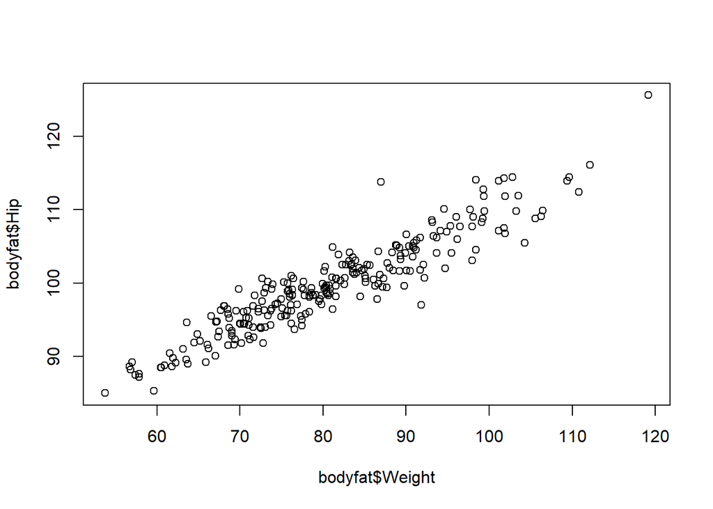

```r
plot(bodyfat$Weight, bodyfat$Hip)
```

```r
cor(bodyfat$Weight, bodyfat$Hip)
```

```
## [1] 0.9326905
```

```r
predict(lm(Pct.BF ~ Hip+Weight, data = bodyfat),
        newdata = data.frame(Hip = 110, Weight = 90), se.fit = TRUE)
```

```
## $fit
##        1
## 26.16744
##
## $se.fit
## [1] 1.138698
##
## $df
## [1] 247
##
## $residual.scale
## [1] 6.418299
```

```r
predict(lm(Pct.BF ~ Hip, data = bodyfat),
        newdata = data.frame(Hip = 110, Weight = 90), se.fit = TRUE)
```

```
## $fit
##        1
## 27.45919
##
## $se.fit
## [1] 0.7712153
##
## $df
## [1] 248
##
## $residual.scale
## [1] 6.435957
```

```r
predict(lm(Pct.BF ~ Weight, data = bodyfat),
        newdata = data.frame(Hip = 110, Weight = 90), se.fit = TRUE)
```

```
## $fit
##        1
## 22.88859
##
## $se.fit
## [1] 0.5181005
##
## $df
## [1] 248
##
## $residual.scale
## [1] 6.538267
```

```r
sort(car::vif(fit_all))
```

```
##     Ankle       Age   Forearm     Wrist     Bicep    Height      Neck      Knee
##  1.810253  2.278191  2.422878  3.263677  3.409524  3.439587  3.978898  4.441752
##     Thigh     Chest     Waist       Hip    Weight
##  7.153711 10.712505 11.967579 12.146249 45.298843
```

```r
fit_sub1 <- lm(Pct.BF ~ Age + Forearm + Wrist + Bicep + Height + Neck + Knee + Thigh, data = bodyfat)
anova(fit_sub1, fit_all) # The simpler model gives a worse goodness of fit
```

```
## Analysis of Variance Table
##
## Model 1: Pct.BF ~ Age + Forearm + Wrist + Bicep + Height + Neck + Knee +
##     Thigh
## Model 2: Pct.BF ~ Age + Weight + Height + Neck + Chest + Waist + Hip +
##     Thigh + Knee + Ankle + Bicep + Forearm + Wrist
##   Res.Df    RSS Df Sum of Sq      F    Pr(>F)
## 1    241 7979.2
## 2    236 4273.7  5    3705.4 40.923 < 2.2e-16 ***
## ---
## Signif. codes:  0 '***' 0.001 '**' 0.01 '*' 0.05 '.' 0.1 ' ' 1
```

```r
AIC(fit_sub1, fit_all) # The simpler model gives a worse goodness of fit
```

```
##          df      AIC
## fit_sub1 10 1595.251
## fit_all  15 1449.165
```